# CourseProject-Weight Lifting Exercise

Bocheng huang

2024/6/22

## Load packages

```r
rm(list = ls())
library(caret)
```

## Load data

Reading Weight Lifting Exercise Dataset from the Human Activity Recognition project. This dataset contains 19622 observations and 160 variables. `classe` variable is the outcome, which is the exercise class. In this project, `classe` is predicted based on the other variables.

```r
wle.train = read.csv("data/pml-training.csv", na.strings = c("#DIV/0!","NA",""))
dim(wle.train)
```

```
## [1] 19622   160
```

## Dividing training and testing sets

```r
# make the results reproducible
set.seed(123)

# Split the data into training and testing sets with 70% in the training set
inTrain = createDataPartition(y = wle.train$classe, p = 0.7, list = FALSE)
training = wle.train[inTrain, ]
testing = wle.train[-inTrain, ]
dim(training)
```

```
## [1] 13737   160
```

```r
dim(testing)
```

```
## [1] 5885  160
```

## Selecting variables

Weight Lifting Exercise Dataset containing 160 variables, we need to remove some variables that are not useful for prediction.

At first, variables `X`, `user_name`, `raw_timestamp_part_1`, `raw_timestamp_part_2`, `cvtd_timestamp`, `new_window`, and `num_window` are information records, which are not related to the exercise itself, so it is better to remove them.

```r
# Useless columns
colnames(training)[1:7]
```

```
## [1] "X"                    "user_name"            "raw_timestamp_part_1"
## [4] "raw_timestamp_part_2" "cvtd_timestamp"       "new_window"
## [7] "num_window"
```

```r
# Remove the first 7 columns in both training and testing sets
training = training[, -c(1:7)]
```

```r
unUse = apply(training, 2, function(x) sum(is.na(x))/length(x)> 0.95)
training = training[, !unUse]
```

Some variables have near zero variance, which also requiring removed.

```r
# calculate the near zero variance variables
nzv = nearZeroVar(training, saveMetrics = TRUE)

# variables that will be maintain
maintain = rownames(nzv[!nzv$nzv & !nzv$zeroVar,])
training = training[, maintain]
dim(training)
```

```
## [1] 13737    53
```

53 variables are selected for the training set, and we use `classe` to be our outcome, so we need to remove it from the training set.

```r
# Remove the outcome variable from the training set
training_y = training$classe
training = subset(training, select = -c(classe))
dim(training)
```

```
## [1] 13737    52
```

Finally, 52 variables are selected for the training set.

## Principle Component Analysis

```r
# Preprocess the data with PCA
preProc = preProcess(training, method = "pca", thresh = 0.85)
preProc$numComp # see how many components are selected
```

```
## [1] 15
```

```r
rot = preProc$rotation # see the rotation matrix

# Apply the pre-processing to the training set
trainingPC = predict(preProc, training)
dim(trainingPC)
```

```
## [1] 13737    15
```

## Gradient Boosting Machine

### 1. Train the model

Fit a GBM model with using 10-fold cross-validation to evaluate the model.

```r
# Load the doParallel package
library(doParallel)
```

```r
# Using parallel to speed up the training process
cl <- makePSOCKcluster(10)
registerDoParallel(cl)
# Fitting GBM model with 10-fold cross-validation
mod1 <-  train(trainingPC, training_y, method = "gbm", trControl = trainControl(method = "cv", number = 10, allowParallel = TRUE))
stopImplicitCluster()
mod1
```

```
## Stochastic Gradient Boosting
##
## 13737 samples
##    15 predictor
##     5 classes: 'A', 'B', 'C', 'D', 'E'
##
## No pre-processing
## Resampling: Cross-Validated (10 fold)
## Summary of sample sizes: 12364, 12364, 12362, 12362, 12364, 12365, ...
## Resampling results across tuning parameters:
##
##   interaction.depth  n.trees  Accuracy   Kappa
##   1                   50      0.5399319  0.4087455
##   1                  100      0.5880507  0.4749943
##   1                  150      0.6170967  0.5129446
##   2                   50      0.6334762  0.5337118
##   2                  100      0.6920032  0.6090234
##   2                  150      0.7268000  0.6534539
##   3                   50      0.6816668  0.5958893
##   3                  100      0.7455801  0.6772791
##   3                  150      0.7867088  0.7297260
##
## Tuning parameter 'shrinkage' was held constant at a value of 0.1
##
## Tuning parameter 'n.minobsinnode' was held constant at a value of 10
## Accuracy was used to select the optimal model using the largest value.
## The final values used for the model were n.trees = 150, interaction.depth =
##  3, shrinkage = 0.1 and n.minobsinnode = 10.
```

Plot GBM model

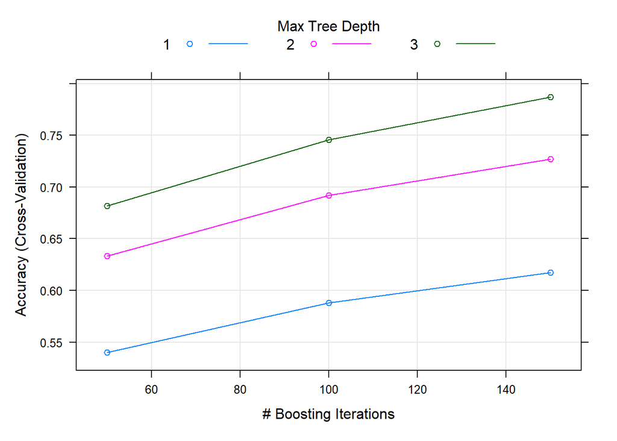

```r
plot(mod1)
```

### 2. Evaluate the model with the testing set

Handle the testing set as the training set.

```r
# Predict the testing set
# Remove the same variables in the testing set
testing = testing[, maintain]
testing_y = testing$classe
testing_y = factor(testing$classe, levels = unique(training_y))
testing = subset(testing, select = -c(classe))
# Apply the pre-processing to the testing set
testingPC = predict(preProc, testing)
```

Now we can evaluate the model with the testing set.

```r
# Predict the testing set
predict1_ts = predict(mod1, testingPC)
CM1 = confusionMatrix(predict1_ts, testing_y, mode = "everything")
CM1
```

```
## Confusion Matrix and Statistics
##
##           Reference
## Prediction    A    B    C    D    E
##          A 1427  153  116   54   57
##          B   53  804   83   32   87
##          C   82  113  796   87   82
##          D   89   33   22  757   46
##          E   23   36    9   34  810
##
## Overall Statistics
##
##                Accuracy : 0.7806
##                  95% CI : (0.7698, 0.7911)
##     No Information Rate : 0.2845
##     P-Value [Acc > NIR] : < 2.2e-16
##
##                   Kappa : 0.7218
##
##  Mcnemar's Test P-Value : < 2.2e-16
##
## Statistics by Class:
##
##                      Class: A Class: B Class: C Class: D Class: E
## Sensitivity            0.8524   0.7059   0.7758   0.7853   0.7486
## Specificity            0.9098   0.9463   0.9251   0.9614   0.9788
## Pos Pred Value         0.7897   0.7592   0.6862   0.7994   0.8882
## Neg Pred Value         0.9394   0.9306   0.9513   0.9581   0.9453
## Precision              0.7897   0.7592   0.6862   0.7994   0.8882
## Recall                 0.8524   0.7059   0.7758   0.7853   0.7486
## F1                     0.8199   0.7316   0.7283   0.7923   0.8124
## Prevalence             0.2845   0.1935   0.1743   0.1638   0.1839
## Detection Rate         0.2425   0.1366   0.1353   0.1286   0.1376
## Detection Prevalence   0.3071   0.1799   0.1971   0.1609   0.1550
## Balanced Accuracy      0.8811   0.8261   0.8505   0.8733   0.8637
```

```r
outOfSampleErr1 = 1 - CM1$overall["Accuracy"]
outOfSampleErr1
```

```
##  Accuracy
## 0.2193713
```

GBM model has an accuracy of 0.7806, out of sample error is 0.2194, which shows the model has a high error rate.

## Random Forest

### 1. Train the model

```r
# Using parallel to speed up the training process
cl <- makePSOCKcluster(10)
registerDoParallel(cl)
# Fitting random forest model with 10-fold cross-validation
mod2 <-  train(trainingPC, training_y, method = "rf", trControl = trainControl(method = "cv", number = 10, allowParallel = TRUE))
stopImplicitCluster()
mod2$finalModel
```

```
##
## Call:
##  randomForest(x = x, y = y, mtry = param$mtry)
##                Type of random forest: classification
##                      Number of trees: 500
## No. of variables tried at each split: 2
##
##         OOB estimate of  error rate: 3.28%
## Confusion matrix:
##      A    B    C    D    E class.error
## A 3829   25   35   15    2  0.01971326
## B   62 2548   41    5    2  0.04138450
## C   18   36 2309   28    5  0.03631052
## D   16   11   98 2121    6  0.05817052
## E    3   16   15   11 2480  0.01782178
```

Plot RF model

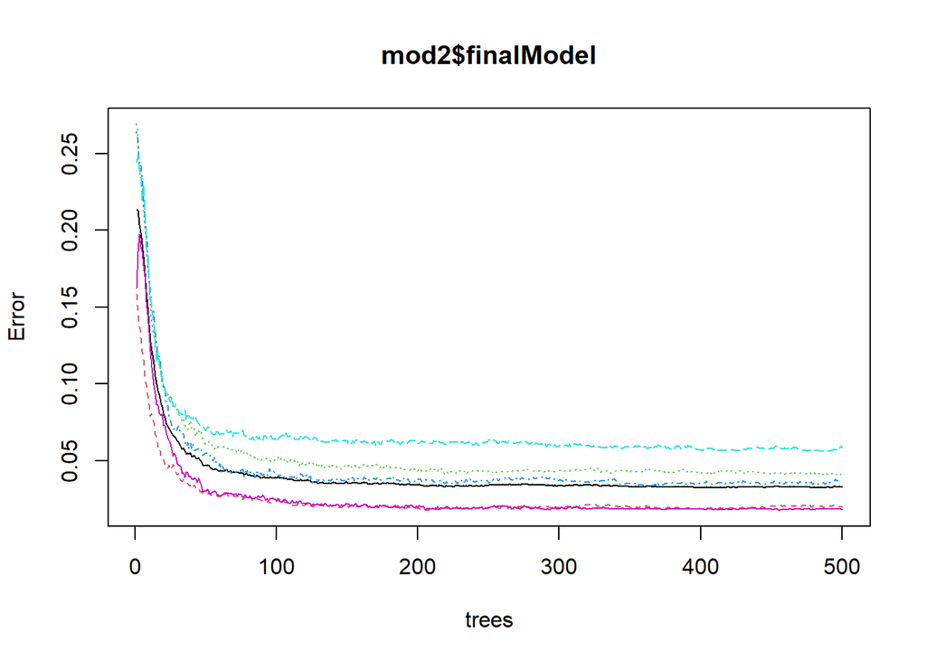

```r
plot(mod2$finalModel)
```

### 2. Evaluate the model with the testing set

Predicting the testing set with Random Forest model.

```r
predict2_ts = predict(mod2, testingPC)
CM2 = confusionMatrix(predict2_ts, testing_y, mode = "everything")
CM2
```

```
## Confusion Matrix and Statistics
##
##           Reference
## Prediction    A    B    C    D    E
##          A 1651   24    6    6    3
##          B    6 1092   18    3    6
##          C   13   18  993   49   10
##          D    3    2    5  904    4
##          E    1    3    4    2 1059
##
## Overall Statistics
##
##                Accuracy : 0.9684
##                  95% CI : (0.9636, 0.9727)
##     No Information Rate : 0.2845
##     P-Value [Acc > NIR] : < 2.2e-16
##
##                   Kappa : 0.96
##
##  Mcnemar's Test P-Value : 2.368e-08
##
## Statistics by Class:
##
##                      Class: A Class: B Class: C Class: D Class: E
## Sensitivity            0.9863   0.9587   0.9678   0.9378   0.9787
## Specificity            0.9907   0.9930   0.9815   0.9972   0.9979
## Pos Pred Value         0.9769   0.9707   0.9169   0.9847   0.9906
## Neg Pred Value         0.9945   0.9901   0.9931   0.9879   0.9952
## Precision              0.9769   0.9707   0.9169   0.9847   0.9906
## Recall                 0.9863   0.9587   0.9678   0.9378   0.9787
## F1                     0.9816   0.9647   0.9417   0.9607   0.9847
## Prevalence             0.2845   0.1935   0.1743   0.1638   0.1839
## Detection Rate         0.2805   0.1856   0.1687   0.1536   0.1799
## Detection Prevalence   0.2872   0.1912   0.1840   0.1560   0.1816
## Balanced Accuracy      0.9885   0.9759   0.9747   0.9675   0.9883
```

```r
outOfSampleErr2 = 1 - CM2$overall["Accuracy"]
outOfSampleErr2
```

```
##   Accuracy
## 0.03160578
```

The model has an accuracy of 0.9684, and out of sample error is 0.0316, which is good enough. We can also see the confusion matrix showing that all metrics are great.

## Conclusion

A Random Forest model with with accuracy of 0.9684 and a GBM model with accuracy of 0.7806 are trained to predict the weight lifting exercise class. The Random Forest model has a higher accuracy than the GBM model. The Random Forest model is selected as the final model to predict the 20 test cases.

# Prediction with test data

```r
dir.create("output")
test_data = read.csv("data/pml-testing.csv", na.strings = c("#DIV/0!","NA",""))
dim(test_data)
```

```
## [1]  20 160
```

Pre-process the test data with PCA.

```r
# Remove the same variables in the testing set
test_data = test_data[, maintain[maintain != "classe"]]

# Apply the pre-processing to the testing set
test_dataPC = predict(preProc, test_data)
dim(test_dataPC)
```

```
## [1] 20 15
```

Predict the test data with Random Forest model.

```r
# Predict the testing set
predict_td = predict(mod2, test_dataPC)
predict_td
```

```
##  [1] B A A A A E D B A A B C B A E E A B B B
## Levels: A B C D E
```

Save output

```r
write.csv(predict_td, file = "output/predictions.csv")
```

## Reference

Velloso, E.; Bulling, A.; Gellersen, H.; Ugulino, W.; Fuks, H. Qualitative Activity Recognition of Weight Lifting Exercises. Proceedings of 4th International Conference in Cooperation with SIGCHI (Augmented Human ’13) . Stuttgart, Germany: ACM SIGCHI, 2013.

Read more: http:/groupware.les.inf.puc-rio.br/har#wle_paper_section#ixzz4TjqYuyDS